# Analysis pipelines - Core functionality and working with R data frames and functions

Naren Srinivasan, Sanjay

8/24/2018

# An overview of the package

# Loading the package

```r
library(analysisPipelines)
```

# Creating an analysisPipeline object

```r
obj <- AnalysisPipeline(filePath = system.file("hotel_new.csv", package = "analysisPipelines"))
```

```
## Creating a new generic function for 'univarCatDistPlots' in the global environment
```

```
## Creating a new generic function for 'outlierPlot' in the global environment
```

```
## Creating a new generic function for 'multiVarOutlierPlot' in the global environment
```

```
## Creating a new generic function for 'ignoreCols' in the global environment
```

```r
obj %>>% setLoggerDetails(target = "file") -> obj
class(obj)
```

```
## [1] "AnalysisPipeline"
## attr(,"package")
## [1] "analysisPipelines"
```

The object created is of type *“AnalysisPipeline”*. The object contains the following attributes:

```r
obj %>>% getInput %>>% str
```

```
## 'data.frame':    858 obs. of  25 variables:
##  $ hotel_id                    : int  1 2 3 4 5 6 7 8 9 10 ...
##  $ max_rooms_capacity          : int  152 156 99 155 112 80 119 110 147 188 ...
##  $ building_type               : Factor w/ 7 levels "13 OR MORE STORIES",..: 2 3 4 3 3 3 3 3 3 7 ...
##  $ location_type               : Factor w/ 9 levels "AIRPORT","DOWNTOWN",..: 7 7 7 3 7 7 7 7 7 3 ...
##  $ Occupancy                   : num  0.878 0.457 0.467 0.434 0.379 ...
##  $ AvgDailyRate                : num  65.2 71.8 81 105.3 73.8 ...
##  $ Compet_Occupancy            : num  0.676 0.479 0.377 0.497 0.318 ...
##  $ Compet_AvgDailyRate         : num  65.5 76.4 80.6 80 59.4 ...
##  $ PercentGovtNights           : num  0.0294 0.0541 0.0234 0.0564 0.0245 ...
##  $ PercentGroupNights          : num  0.10178 0.14198 0.00287 0.16703 0.09789 ...
##  $ PercentTransientNights      : num  0.869 0.804 0.974 0.777 0.878 ...
##  $ PercentBusiness             : num  0.297 0.181 0.284 0.267 0.492 ...
##  $ PercentLeisure              : num  0.703 0.819 0.716 0.733 0.508 ...
##  $ hotelcount1mile             : int  1 0 1 1 1 2 1 2 0 0 ...
##  $ hotelcount5mile             : int  1 1 1 2 1 2 1 2 2 3 ...
##  $ rooms1mile                  : int  22 0 47 38 63 65 71 77 0 0 ...
##  $ rooms5mile                  : int  22 27 47 56 63 65 71 77 89 90 ...
##  $ loyalty_pct                 : num  0.321 0.206 0.342 0.307 0.541 ...
##  $ call_center_booking_pct     : num  0.0472 0.0484 0.1544 0.2132 0.0646 ...
##  $ travel_agency_booking_pct   : num  0.02545 0.01941 0.0801 0.00927 0.22026 ...
##  $ third_party_web_bookings_pct: num  0.00761 0.00715 0.00336 0.00177 0.00816 ...
##  $ hotel_to_hotel_bookings_pct : num  0 0 0 0.000441 0.005438 ...
##  $ direct_call_booking_pct     : num  0.889 0.872 0.671 0.656 0.589 ...
##  $ direct_web_booking_pct      : num  0.0304 0.0535 0.0916 0.1196 0.1128 ...
##  $ Class                       : Factor w/ 2 levels "bad","good": 2 1 1 1 1 1 1 1 1 1 ...
```

```r
obj %>>% getRegistry
```

```
## # A tibble: 4 x 6
##   functionName  heading   engine exceptionHandli… userDefined dataFunction
##   <chr>         <chr>     <chr>  <chr>            <lgl>       <lgl>
## 1 univarCatDis… Univaria… r      genericPipeline… FALSE       NA
## 2 outlierPlot   Univaria… r      genericPipeline… FALSE       NA
## 3 multiVarOutl… Multivar… r      genericPipeline… FALSE       NA
## 4 ignoreCols    ""        r      genericPipeline… FALSE       NA
```

# Chaining operations

```r
# Running univariate categorical distribution plot on the constructed object

obj1 <- obj %>>% univarCatDistPlots(uniCol = "building_type", priColor = "blue", optionalPlots = 0, storeOutput = T)
obj1 %>>% getPipeline
```

```
## # A tibble: 1 x 6
##   id    operation          heading          parameters outAsIn storeOutput
##   <chr> <chr>              <chr>            <list>     <lgl>   <lgl>
## 1 1     univarCatDistPlots Univariate Dist… <list [3]> FALSE   TRUE
```

```r
# Running univariate categorical distribution plot and then
# outlier detection on the constructed object

obj %>>% univarCatDistPlots(uniCol = "location_type", priColor = "xy", optionalPlots = 0) %>>%
         outlierPlot(method = "iqr", columnName = "Occupancy",
              cutoffValue = 0.01, priColor = "blue", optionalPlots = 0, storeOutput = T) -> obj2
obj2 %>>% getPipeline
```

```
## # A tibble: 2 x 6
##   id    operation          heading          parameters outAsIn storeOutput
##   <chr> <chr>              <chr>            <list>     <lgl>   <lgl>
## 1 1     univarCatDistPlots Univariate Dist… <list [3]> FALSE   FALSE
## 2 2     outlierPlot        Univariate Outl… <list [5]> FALSE   TRUE
```

# Lazy evaluation

```r
length(obj1@output)
```

```
## [1] 0
```

However, a specific function call can generate the output of the pipeline stored in the object. Which is then stored in the *output* attribute of the object.

```r
obj1Output <- obj1 %>>% generateOutput
length(obj1Output@output)
```

```
## [1] 1
```

Observe that the length of the output list of the first object (the chunk above) remains 0 since the generated output was assigned to a new object.

```r
length(obj1@output)
```

```
## [1] 0
```

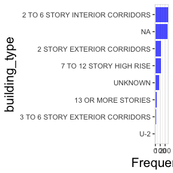

```r
# The index can range from 1 to length(obj@output)
obj1Output %>>% getOutputById("1")
```

# User-defined functions

## Registering your own function

On invoking the constructor, i.e., creating an object of type AnalysisPipeline, the functions defined in the list are *registered* for the said object. The list of registered functions can be viewed as *obj@registry*. The package has the option to add any user-defined function to this list of functions,  
The only **constraint** for registering an user-defined function is that the first parameter in the argument list must be a data frame.  
Let us demonstrate this with an example.

```r
# Currently registered functions
obj2 %>>% getRegistry()
```

```
## # A tibble: 4 x 6
##   functionName  heading   engine exceptionHandli… userDefined dataFunction
##   <chr>         <chr>     <chr>  <chr>            <lgl>       <lgl>
## 1 univarCatDis… Univaria… r      genericPipeline… FALSE       NA
## 2 outlierPlot   Univaria… r      genericPipeline… FALSE       NA
## 3 multiVarOutl… Multivar… r      genericPipeline… FALSE       NA
## 4 ignoreCols    ""        r      genericPipeline… FALSE       NA
```

Currently, the package does not have a function to plot bivariate distributions. Let us define a function which can do it for us.

```r
bivariatePlots <- function(object, select_var_name_1, select_var_name_2,
                       priColor = "blue", secColor='black') {
  x=object[, select_var_name_1]
  y=object[, select_var_name_2]
  bivarPlot <- ggplot2::ggplot(object, ggplot2::aes(x,y)) +
    ggplot2::geom_point(color=priColor,alpha=0.7) +
    ggplot2::geom_smooth(method = lm,color=secColor) +
    ggplot2::xlab(select_var_name_1) +
    ggplot2::ylab(select_var_name_2) +
    ggplot2::theme_bw() +
    ggplot2::ggtitle(paste('Bivariate plot for', select_var_name_1,
                           'and', select_var_name_2, sep=' ')) +
    ggplot2::theme(plot.title = ggplot2::element_text(hjust = 0.5, size = 10),
                   axis.text = ggplot2::element_text(size=10),
                   axis.title=ggplot2::element_text(size=10))
  return(bivarPlot)
}
```

This user-defined function can now be registered as part of the AnalysisPipeline object created. Following which, the updated registry will show that the object has at its disposal an additional function which was not defined in the utility.

```r
# The first parameter provides the function name
# The second parameter allows for a header that will feature in the report
# The exceptionFunction parameter allows the user to define a custom exception function in case there is an error during execution
bivarException <- function(error){
  stop("There was an error while plotting bivariate plots due to the provided parameters")
}
obj2 <- obj2 %>>% registerFunction('bivariatePlots', "Bivariate Plots", exceptionFunction = "bivarException")

# Printing the updated registry
obj2 %>>% getRegistry
```

```
## # A tibble: 5 x 6
##   functionName  heading   engine exceptionHandli… userDefined dataFunction
##   <chr>         <chr>     <chr>  <chr>            <lgl>       <lgl>
## 1 univarCatDis… Univaria… r      genericPipeline… FALSE       NA
## 2 outlierPlot   Univaria… r      genericPipeline… FALSE       NA
## 3 multiVarOutl… Multivar… r      genericPipeline… FALSE       NA
## 4 ignoreCols    ""        r      genericPipeline… FALSE       NA
## 5 bivariatePlo… Bivariat… r      bivarException   TRUE        NA
```

## Using the newly registered function with lazy eval of pipeline

Now that a new user-defined function is also available along with the existing functions, all the features can be leveraged in unison.

```r
# Chaining the user-defined function to the object's pipeline where it was registered
obj2 <- obj2 %>>%
  bivariatePlots(select_var_name_1 = 'Occupancy', select_var_name_2 = 'max_rooms_capacity',
                 priColor = "blue", secColor = "black")

# Printing the updated pipeline
obj2 %>>% getPipeline
```

```
## # A tibble: 3 x 6
##   id    operation          heading          parameters outAsIn storeOutput
##   <chr> <chr>              <chr>            <list>     <lgl>   <lgl>
## 1 1     univarCatDistPlots Univariate Dist… <list [3]> FALSE   FALSE
## 2 2     outlierPlot        Univariate Outl… <list [5]> FALSE   TRUE
## 3 3     bivariatePlots     Bivariate Plots  <list [4]> FALSE   FALSE
```

The newly added function will also lazy evaluate depending on the trigger.

```r
obj2Output <- obj2 %>>% generateOutput()
obj2Output %>>% getOutputById("1") -> a
a
```

```
## $call
## # A tibble: 1 x 7
##   id    operation   heading    parameters outAsIn storeOutput dependencies
##   <chr> <chr>       <chr>      <list>     <lgl>   <lgl>       <list>
## 1 1     univarCatD… Univariat… <list [3]> FALSE   FALSE       <chr [0]>
##
## $output
## [1] "The output of this function was not configured to be stored"
```

```r
obj2Output@pipeline
```

```
## # A tibble: 3 x 7
##   id    operation   heading    parameters outAsIn storeOutput dependencies
##   <chr> <chr>       <chr>      <list>     <lgl>   <lgl>       <list>
## 1 1     univarCatD… Univariat… <list [3]> FALSE   FALSE       <chr [0]>
## 2 2     outlierPlot Univariat… <list [5]> FALSE   TRUE        <chr [0]>
## 3 3     bivariateP… Bivariate… <list [4]> FALSE   TRUE        <chr [0]>
```

# Complex pipelines

## Using the outputs of previous functions in the pipeline, as inputs to arbitrary parameters of subsequent functions

```r
getColor <- function(data, color){
  return(color)
}

getColumnName <-function(data, columnName){
  return(columnName)
}


obj %>>% registerFunction("getColor") -> obj

obj %>>% registerFunction("getColumnName") -> obj

obj %>>% getRegistry
```

```
## # A tibble: 6 x 6
##   functionName  heading   engine exceptionHandli… userDefined dataFunction
##   <chr>         <chr>     <chr>  <chr>            <lgl>       <lgl>
## 1 univarCatDis… Univaria… r      genericPipeline… FALSE       NA
## 2 outlierPlot   Univaria… r      genericPipeline… FALSE       NA
## 3 multiVarOutl… Multivar… r      genericPipeline… FALSE       NA
## 4 ignoreCols    ""        r      genericPipeline… FALSE       NA
## 5 getColor      ""        r      genericPipeline… TRUE        NA
## 6 getColumnName ""        r      genericPipeline… TRUE        NA
```

```r
obj %>>% getColor(color = "blue") %>>% getColumnName(columnName = "Occupancy", storeOutput = T) %>>%
      univarCatDistPlots(uniCol = "building_type", priColor = ~f1, optionalPlots = 0, storeOutput = T) %>>%
      outlierPlot(method = "iqr", columnName = ~f2, cutoffValue = 0.01, priColor = ~f1 , optionalPlots = 0) -> complexPipeline

complexPipeline %>>% getPipeline
```

```
## # A tibble: 4 x 6
##   id    operation          heading          parameters outAsIn storeOutput
##   <chr> <chr>              <chr>            <list>     <lgl>   <lgl>
## 1 1     getColor           ""               <list [1]> FALSE   FALSE
## 2 2     getColumnName      ""               <list [1]> FALSE   TRUE
## 3 3     univarCatDistPlots Univariate Dist… <list [3]> FALSE   TRUE
## 4 4     outlierPlot        Univariate Outl… <list [5]> FALSE   FALSE
```

```r
complexPipeline %>>% visualizePipeline
```

[interactive chart not shown]

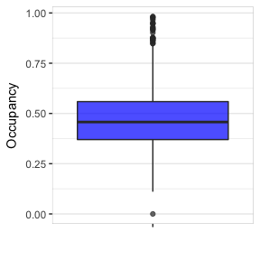

```r
complexPipeline %>>% generateOutput -> op

op %>>% getOutputById("4")
```

# Generating reports

Object and lists stored in the memory are not consumable. Hence, the package allows for the option to knit a pipeline’s outputs into a neat HTML file, which can serve as a report of the analysis performed.

```r
# generateReport() needs a destination path as an argument
# The function writes a HTML file

obj2Output %>>% generateReport('~/Desktop')
```

In the above case, since the object had the output evaluated and stored in the *output* attribute, the function call only knits the output into an HTML file.  
In the example below, the object has an empty output attribute. The function call, in this case, evaluates the outputs and then knits them into an HTML file.

```r
objRep <- obj %>>% bivariatePlots('Occupancy', 'PercentTransientNights',
                           priColor = "blue", secColor = "black")

objRep %>>% generateReport('~/Desktop')
```

**NOTE**: A sample of the above report can be found in the *support/* folder of the utility.

# Saving and loading pipelines

The pipelines stored as an attribute in the object are effectively meta pipelines which document the steps in an EDA pipeline. These can be exported and re-read by certain functions available in this EDA utility. The pipelines are generic enough to work with the schema of the data that was used to invoke the constructor. Therefore, this pipeline can be used on any data of the same schema.

```r
# Saves the pipeline and registry of the EDA object
savePipeline(obj2, 'pipeline.RDS')
```

This pipeline can be loaded and re-used with any other data set.

```r
obj2 <- loadPipeline('pipeline.RDS',filePath = system.file("hotel_new.csv", package = "analysisPipelines"))

obj2 %>% getRegistry
```

```
## # A tibble: 5 x 6
##   functionName  heading   engine exceptionHandli… userDefined dataFunction
##   <chr>         <chr>     <chr>  <chr>            <lgl>       <lgl>
## 1 univarCatDis… Univaria… r      genericPipeline… FALSE       NA
## 2 outlierPlot   Univaria… r      genericPipeline… FALSE       NA
## 3 multiVarOutl… Multivar… r      genericPipeline… FALSE       NA
## 4 ignoreCols    ""        r      genericPipeline… FALSE       NA
## 5 bivariatePlo… Bivariat… r      bivarException   TRUE        NA
```

```r
obj2 %>% getPipeline
```

```
## # A tibble: 3 x 6
##   id    operation          heading          parameters outAsIn storeOutput
##   <chr> <chr>              <chr>            <list>     <lgl>   <lgl>
## 1 1     univarCatDistPlots Univariate Dist… <list [3]> FALSE   FALSE
## 2 2     outlierPlot        Univariate Outl… <list [5]> FALSE   TRUE
## 3 3     bivariatePlots     Bivariate Plots  <list [4]> FALSE   FALSE
```

# Logging & Execution times

# Parallel execution of all-R pipelines